# Introduction to Clustering

Author

Lieven Clement

# 1 Introduction

## 1.1 Objective

Objective: grouping of observations into **clusters**, so that

- similar observations appear in the same cluster
- dissimilar observations appear in distinct clusters

$\longrightarrow$ need for a measure for **similarity** and **dissimilarity**?

## 1.2 Example 1

Single cell transcriptomics: $n \times p$ Matrix for which

- every column contains the expression levels of one of $p$ genes for $n$ cells
- every row contains the expression levels of $p$ genes for one cell (**sample**)
- Research question: look for groups of cells that have similar gene expression patterns
- Or, look for groups of genes that have similar expression levels across the different cells. This can help us in understanding the regulation and functionality of the genes.

$\longrightarrow$ both **observations** (rows) and **variables** (columns) can be clustered

## 1.3 Example 2

Abundance studies: the abundances of $n$ plant species are counted on $p$ plots (habitats)

- look for groups that contain species that live in the same habitats, or, look for groups of habitats that have similar species communities

$\longrightarrow$ both **observations** (rows) and **variables** (columns) can be clustered

# 2 Partition Based Cluster Analysis

- Partition based cluster methods require the number of clusters (k) to be specified prior to the start of the algorithm.

## 2.1 K-means Methods

- To use the k-means clustering algorithm we have to pre-define $k$, the number of clusters we want to define.
- The k-means algorithm is iterative.
- The algorithm starts by defining k cluster centers (centroids).
- Then the algorithm proceeds as follows
  1. First each observation is assigned to the cluster with the closest center to that observation.
  2. Then the k centers are redefined using the observations in each cluster, i.e. the multivariate means (column means) of all observations in a cluster are used to define each new cluster center.
  3. We repeat these two steps until the centers converge.

## 2.2 Example

```r
library(tidyverse)
data(diabetes,package = "mclust")
class <- diabetes$class
table(class)
```

```
#> class
#> Chemical   Normal    Overt
#>       36       76       33
```

```r
head(diabetes)
```

|  | class | glucose | insulin | sspg |
| --- | --- | --- | --- | --- |
| 1 | Normal | 80 | 356 | 124 |
| 2 | Normal | 97 | 289 | 117 |
| 3 | Normal | 105 | 319 | 143 |
| 4 | Normal | 90 | 356 | 199 |
| 5 | Normal | 90 | 323 | 240 |
| 6 | Normal | 86 | 381 | 157 |

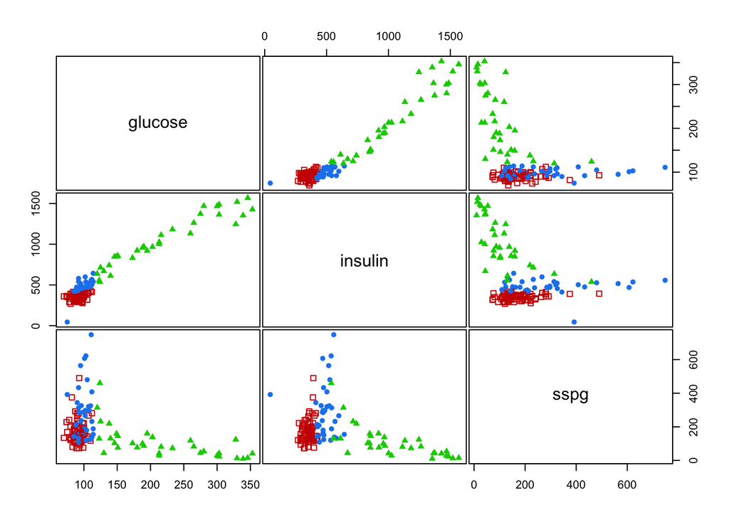

```r
mclust::clPairs(diabetes[,-1], diabetes$class)
```

```r
diabetesKmeans <- kmeans(diabetes[,-1], centers = 3)
diabetesKmeans
```

```
#> K-means clustering with 3 clusters of sizes 26, 25, 94
#>
#> Cluster means:
#>     glucose   insulin      sspg
#> 1 241.65385 1152.8846  75.69231
#> 2 105.04000  525.6000 375.96000
#> 3  93.39362  375.5213 166.17021
#>
#> Clustering vector:
#>   1   2   3   4   5   6   7   8   9  10  11  12  13  14  15  16  17  18  19  20
#>   3   3   3   3   3   3   3   3   3   3   3   3   3   3   3   3   3   3   3   3
#>  21  22  23  24  25  26  27  28  29  30  31  32  33  34  35  36  37  38  39  40
#>   3   3   3   3   3   3   3   3   3   3   3   3   3   3   3   3   3   3   3   3
#>  41  42  43  44  45  46  47  48  49  50  51  52  53  54  55  56  57  58  59  60
#>   3   3   3   3   3   3   3   3   3   3   3   3   3   3   3   3   3   3   3   3
#>  61  62  63  64  65  66  67  68  69  70  71  72  73  74  75  76  77  78  79  80
#>   3   3   3   3   3   3   3   3   2   3   2   3   3   3   3   3   3   3   3   3
#>  81  82  83  84  85  86  87  88  89  90  91  92  93  94  95  96  97  98  99 100
#>   3   2   3   3   3   2   2   3   2   2   2   2   2   2   2   3   2   2   2   2
#> 101 102 103 104 105 106 107 108 109 110 111 112 113 114 115 116 117 118 119 120
#>   2   2   3   3   3   2   3   2   3   3   2   3   1   1   2   1   1   1   1   1
#> 121 122 123 124 125 126 127 128 129 130 131 132 133 134 135 136 137 138 139 140
#>   1   1   1   3   1   1   1   1   1   1   2   1   1   3   3   2   2   1   1   1
#> 141 142 143 144 145
#>   1   1   1   1   1
#>
#> Within cluster sum of squares by cluster:
#> [1] 1738796.1  687281.9  947827.2
#>  (between_SS / total_SS =  80.6 %)
#>
#> Available components:
#>
#> [1] "cluster"      "centers"      "totss"        "withinss"     "tot.withinss"
#> [6] "betweenss"    "size"         "iter"         "ifault"
```

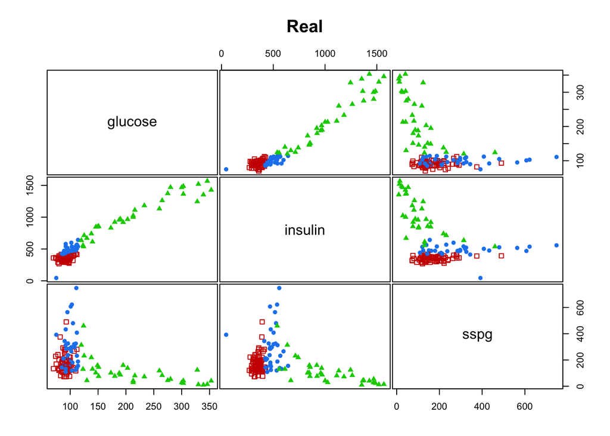

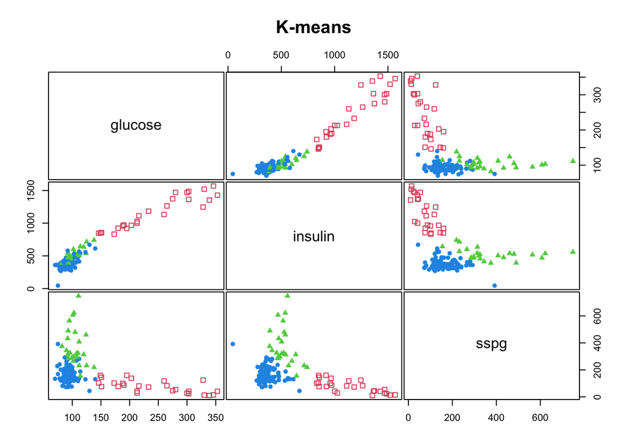

```r
mclust::clPairs(diabetes[,-1], diabetes$class, main = "Real"); mclust::clPairs(diabetes[,-1], diabetesKmeans$cluster,colors = c(2,3,4),symbols = c(0,17,16), main="K-means")
```

# 3 Hierarchical Cluster Analysis

- Distinction between agglomerative and divisive methods
- Agglomerative start from the situation where each individual observations forms its own cluster (so it starts with n clusters). In the next steps clusters are sequentially merged, until finally there is only one cluster with n observations.
- Divisive methods work just the other way around.
- The solution of an hierarchical clustering is thus a sequence of n nested cluster solutions.

## 3.1 General Algorithm of Agglomerative Hierarchical Clustering

- In step 0 each observations is considered as a cluster (i.e. $n$ clusters).
- Every next step consists of:
  1. merge the two clusters with the smallest intercluster dissimilarity
  2. recalculate the intercluster dissimilarities

In step 0 the intercluster dissimilarity coincides with the dissimilarity between the corresponding observations

$\rightarrow$ intercluster dissimilarity?

## 3.2 Intercluster Dissimilarities

We consider three intercluster dissimilarities.

### 3.2.1 Single Linkage = Nearest Neighbour

$$d(C_1,C_2) = \min_{\mathbf{x}_1 \in C_1; \mathbf{x}_2 \in C_2}
d(\mathbf{x}_1,\mathbf{x}_2) ,$$

i.e. the dissimilarity between $C_1$ and $C_2$ is determined by the smallest dissimilarity between a point of $C_1$ and a point of $C_2$.

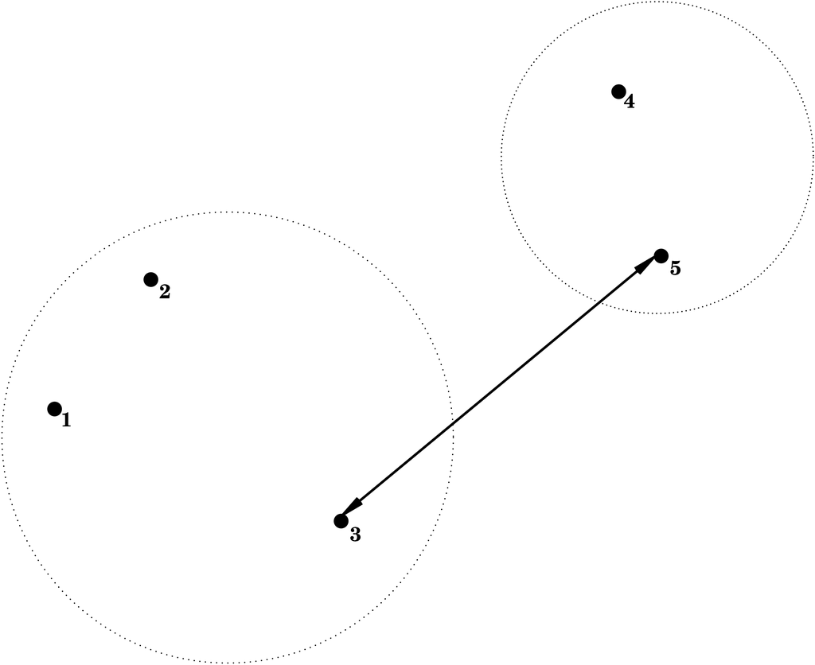

### 3.2.2 Complete Linkage = Furthest Neighbour

$$d(C_1,C_2) = \max_{\mathbf{x}_1 \in C_1; \mathbf{x}_2 \in C_2}
d(\mathbf{x}_1,\mathbf{x}_2) ,$$
i.e. the dissimilarity between $C_1$ and $C_2$ is determined by the largest dissimilarity between a point of $C_1$ and a point of $C_2$.

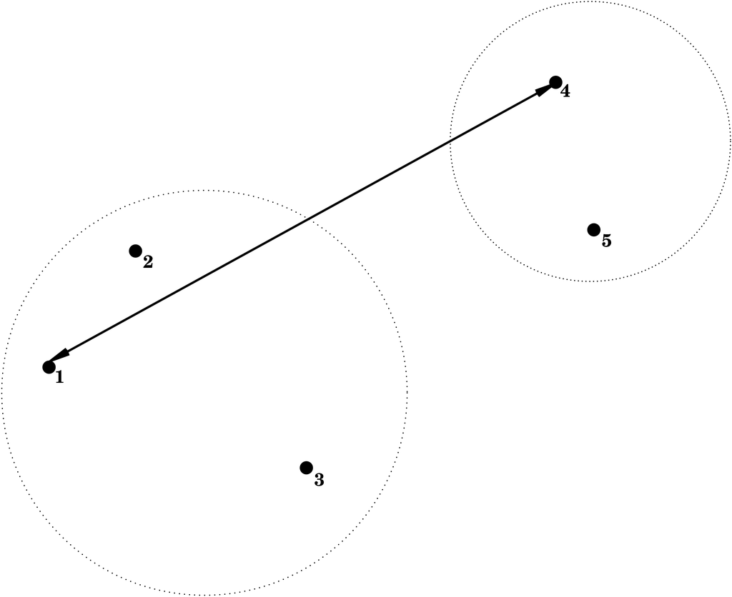

### 3.2.3 Average Linkage = Group Average

$$d(C_1,C_2) = \frac{1}{\vert C_1 \vert \vert C_2 \vert}
\sum_{\mathbf{x}_1 \in C_1; \mathbf{x}_2 \in C_2}
d(\mathbf{x}_1,\mathbf{x}_2) ,$$
i.e. the dissimilarity between $C_1$ and $C_2$ is determined by the average dissimilarity between all points of $C_1$ and all points of $C_2$.

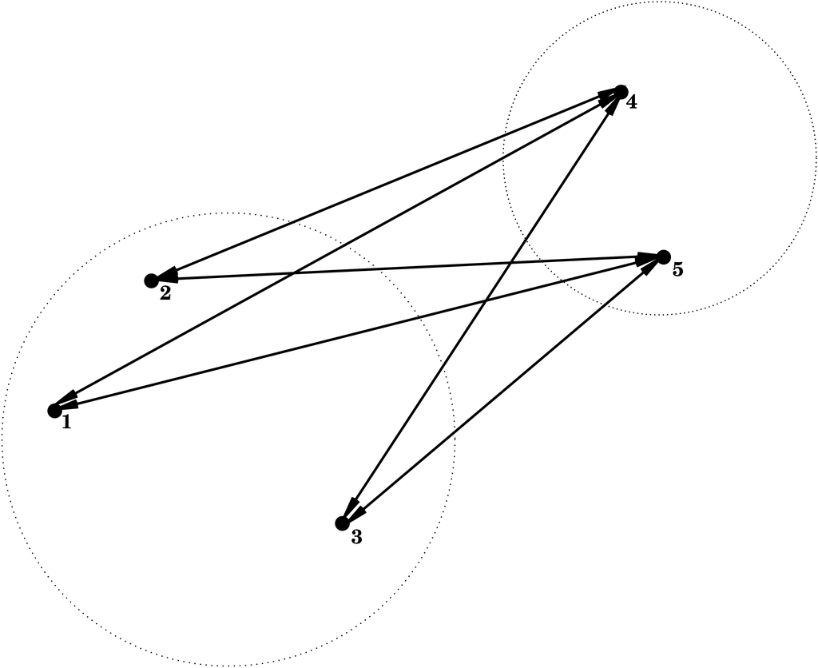

## 3.3 Cluster Tree

Hierarchical nature of the algorithm:

- Nested sequence of clusters $\longrightarrow$ visualisation via a tree
- Height of branches indicate the intercluster dissimilarity at which clusters are merged.
- Can used as instrument for deciding the number of clusters in the data

# 4 Toy example

| X1 | X2 | label |
| --- | --- | --- |
| 1.50 | 2.40 | 1 |
| 2.00 | 2.50 | 2 |
| 2.50 | 2.25 | 3 |
| 2.00 | 3.00 | 4 |
| 2.25 | 3.20 | 5 |

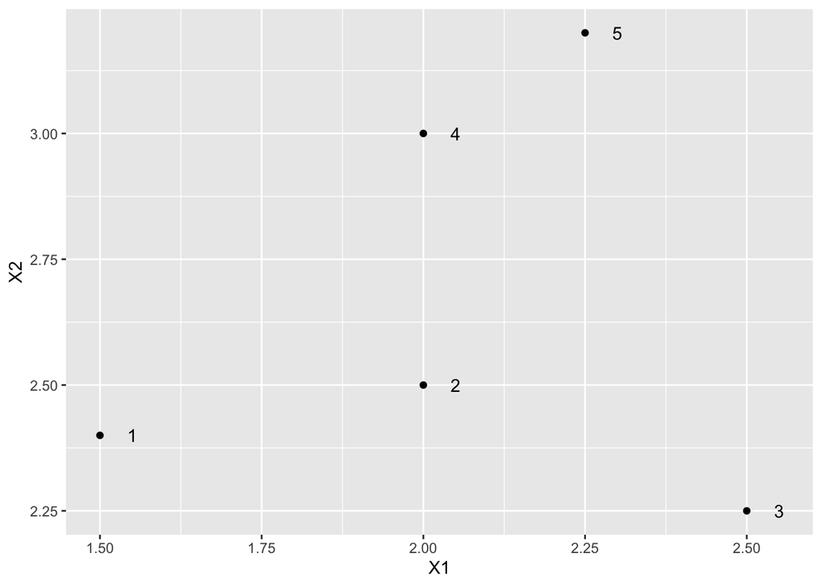

```r
toy |>
  ggplot(aes(X1, X2, label = label)) +
  geom_point() +
  geom_text(nudge_x = .05)
```

```r
toy[,1:2] |> dist()
```

```
#>           1         2         3         4
#> 2 0.5099020
#> 3 1.0111874 0.5590170
#> 4 0.7810250 0.5000000 0.9013878
#> 5 1.0965856 0.7433034 0.9823441 0.3201562
```

## 4.1 Single linkage

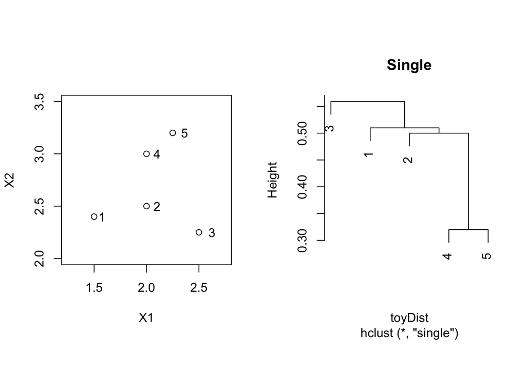

```r
toyDist <- toy[,1:2] |> dist()
toySingle <- hclust(toyDist, method = "single")
par(mfrow=c(1,2),pty="s")
plot(X2 ~ X1, toy, xlim = c(1.25,2.75),ylim = c(2,3.5))
text(toy$X1*1.05,toy$X2,label=toy$label)
plot(toySingle, main = "Single")
```

```r
toyDist
```

```
#>           1         2         3         4
#> 2 0.5099020
#> 3 1.0111874 0.5590170
#> 4 0.7810250 0.5000000 0.9013878
#> 5 1.0965856 0.7433034 0.9823441 0.3201562
```

## 4.2 Complete linkage

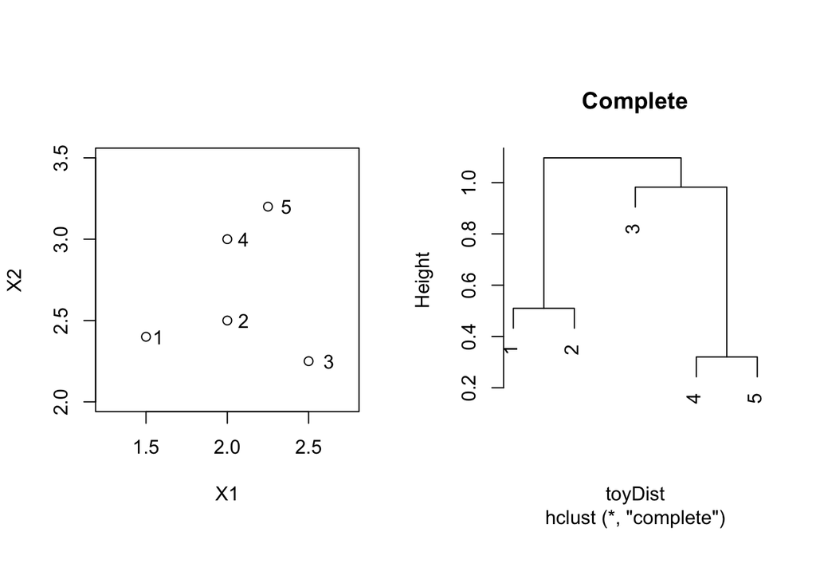

```r
toyComplete <- hclust(toyDist, method = "complete")
par(mfrow=c(1,2),pty="s")
plot(X2 ~ X1, toy, xlim = c(1.25,2.75),ylim = c(2,3.5))
text(toy$X1*1.05,toy$X2,label=toy$label)
plot(toyComplete,  main = "Complete")
```

```r
toyDist
```

```
#>           1         2         3         4
#> 2 0.5099020
#> 3 1.0111874 0.5590170
#> 4 0.7810250 0.5000000 0.9013878
#> 5 1.0965856 0.7433034 0.9823441 0.3201562
```

## 4.3 Average linkage

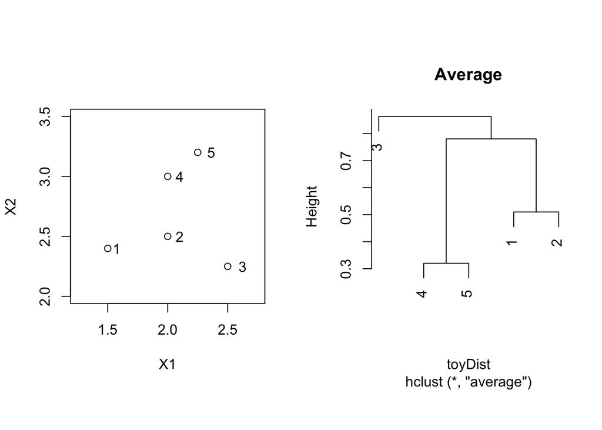

```r
toyAvg <- hclust(toyDist, method = "average")
par(mfrow=c(1,2),pty="s")
plot(X2 ~ X1, toy, xlim = c(1.25,2.75),ylim = c(2,3.5))
text(toy$X1*1.05,toy$X2,label=toy$label)
plot(toyAvg, main = "Average")
```

```r
toyDist
```

```
#>           1         2         3         4
#> 2 0.5099020
#> 3 1.0111874 0.5590170
#> 4 0.7810250 0.5000000 0.9013878
#> 5 1.0965856 0.7433034 0.9823441 0.3201562
```

## 4.4 Example

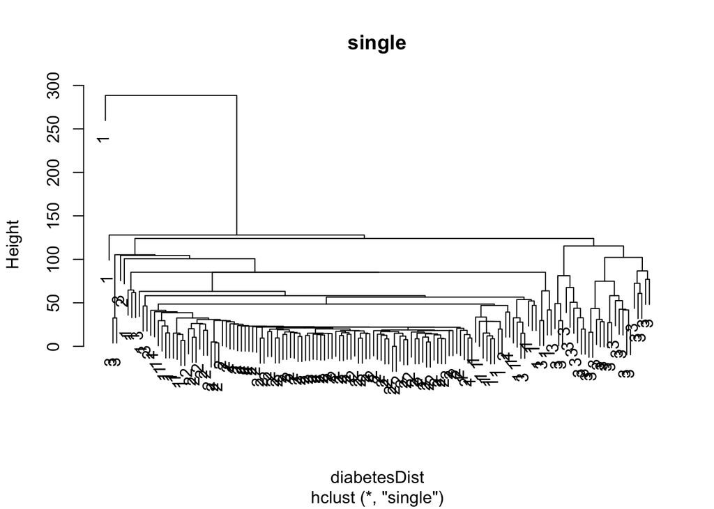

```r
diabetesDist <- dist(diabetes[,-1])
diabetesSingle <- hclust(diabetesDist, method = "single")
plot(diabetesSingle, labels = as.double(diabetes$class), main="single")
```

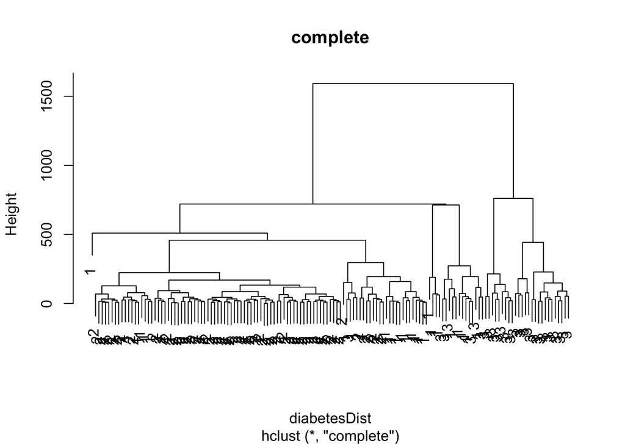

```r
diabetesComplete <- hclust(diabetesDist, method = "complete")
plot(diabetesComplete, labels = as.double(diabetes$class), main="complete")
```

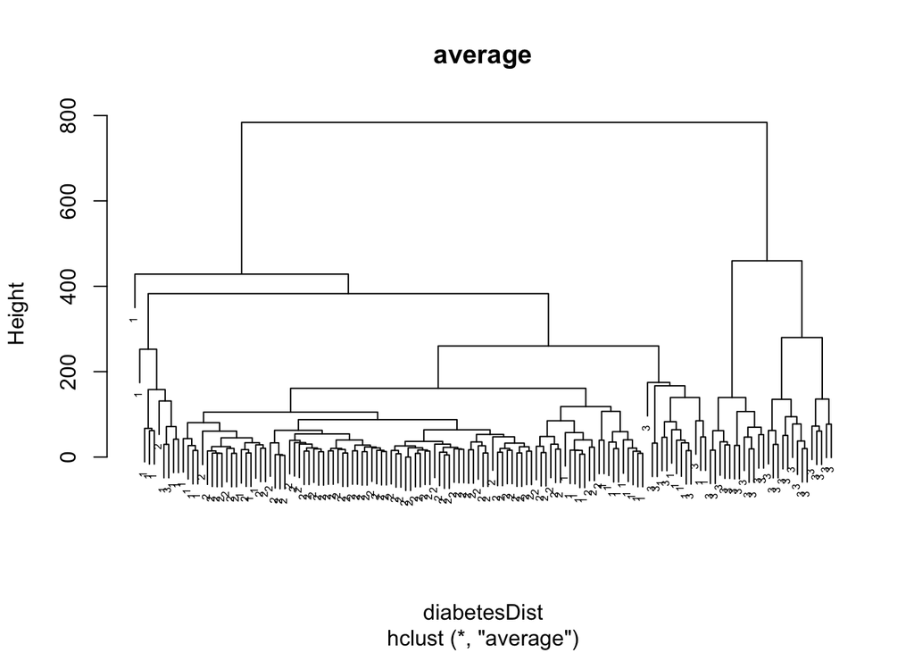

```r
diabetesAverage <- hclust(diabetesDist, method = "average")
plot(diabetesAverage, labels = as.double(diabetes$class), main = "average",cex=0.5)
```

# 5 Model-based clustering

- [Paper: Fraley and Raftery (1998). How Many Clusters? Which Clustering Method? Answers Via Model-Based Cluster Analysis. The Computer Journal, (41)8:578-588.](https://sites.stat.washington.edu/people/raftery/Research/PDF/fraley1998.pdf)
- EM algorithm [PDF]
- Example: see tutorial session

# Session info

**Session info**

```
#> [1] "2026-09-15 16:45:20 CEST"
```